# Introduction to Portfolio Analysis in R

## Intro

- Avoid large losses – diversify portfolio – use backtesting

## Portfolio Weights and Returns

```r
getSymbols(symbls, auto.assign = T)
```

```
[1] "AAPL" "MSFT" "GSPC"
```

Ratio expressing the value of the share price of Apple in terms of the share price of Microsoft

Note that where the value of the ratio is larger than one, the Apple outperforms Microsoft and vice versa.

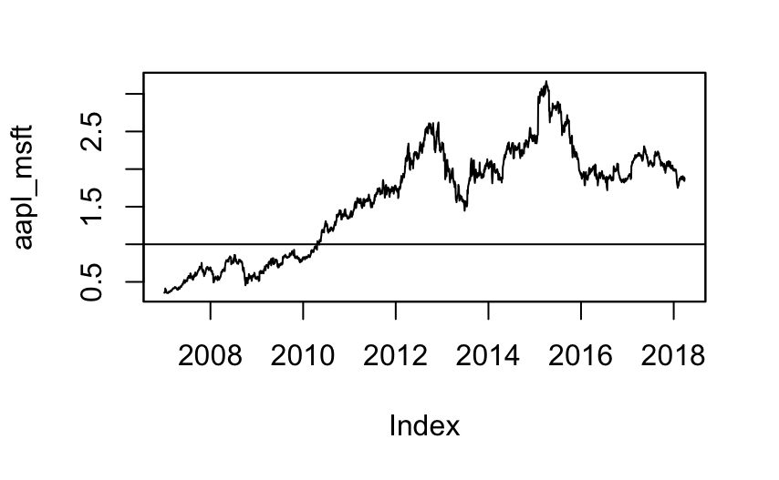

```r
aapl_msft = AAPL$AAPL.Adjusted/MSFT$MSFT.Adjusted
plot.zoo(aapl_msft)
abline(h=1)
```

### Asset Weight

- Equal weighting

```r
N = 2
weights <- rep(1/N,N)
weights
```

```
[1] 0.5 0.5
```

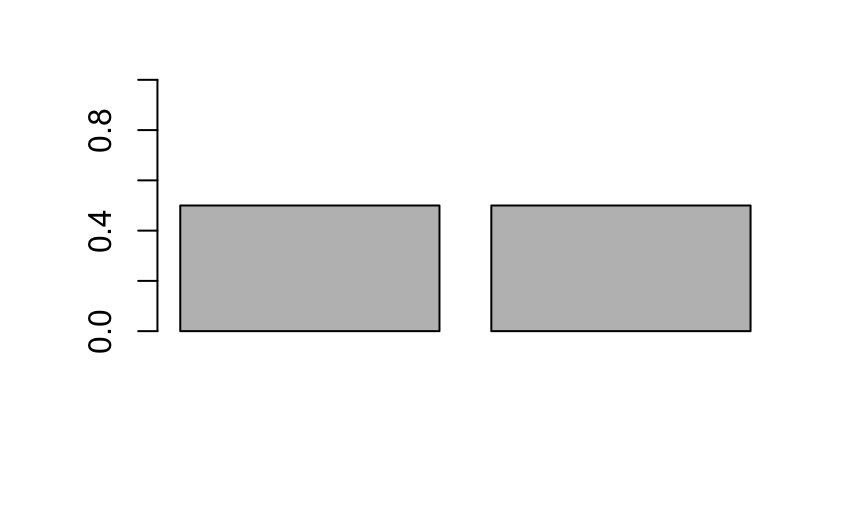

```r
barplot(weights, ylim = 0:1)
```

- Market Cap weighting

```r
# Define the vector values
values <- c(4000, 6000)

# Define the vector weights
weights <- values/sum(values)

# Print the resulting weights
## Should sum up to unity
weights
barplot(weights, ylim = 0:1)
```

[output not shown]

### Portfolio Returns

$$Portfolio Returns = w_1R_1 + w_2R_2 + ... + w_nR_n$$

```r
# Vector of initial value of the assets
in_values <- c(1000,5000,2000)

# Vector of final values of the assets
fin_values <- c(1100, 4500, 3000)
# Weights as the proportion of total value invested in each assets
weights <- in_values/sum(in_values)
weights
```

```
[1] 0.125 0.625 0.250
```

```r
# Vector of simple returns of the assets
returns <- (fin_values - in_values)/in_values
returns
```

```
[1]  0.1 -0.1  0.5
```

```r
# Compute portfolio return using the portfolio return formula
preturns <- sum(weights*returns)
preturns
```

```
[1] 0.075
```

#### From simple to gross and multi-period returns

The simple return $R$ expresses the percentage change in value of an investment. The corresponding so-called “gross” return is defined as the future value of 1 USD invested in the asset for one period, and is thus equal to $1+R$

The gross return over two periods is obtained similarly. Let $R_1$ be the return in the first period and $R_2$ the return in the second period. Then the end-value of a 1 USD investment is $(1+R_1)∗(1+R_2)$

The corresponding simple return over those two periods is: $(1+R_1)∗(1+R_2)−1$

Suppose that you have an investment horizon of two periods. In the first period you make a 10% return. But in the second period you take a loss of 5%.

```r
(1+.1)*(1-.05)*1000
```

[output not shown]

#### The asymmetric impact of gains and losses

It is important to be aware of the fact that a positive and negative return of the same relative magnitude do not compensate each other in terms of terminal wealth. Mathematically, this can be seen from the identity $(1+x)∗(1−x)=1−x^2$, which is less than one. A 50% loss is thus not compensated by a 50% gain. After a loss of 50%, what is the return needed to be at par again?

```r
(1-.5)*(1+1)
```

```
[1] 1
```

### PerformanceAnalytics

```r
head(returns, n=2)
```

```
                   AAPL         MSFT
2007-01-04  0.022195701 -0.001674669
2007-01-05 -0.007121306 -0.005702811
```

### Buy-and-hold versus (daily) rebalancing

- Set initial weigths and do not intervene
- Actively change weights

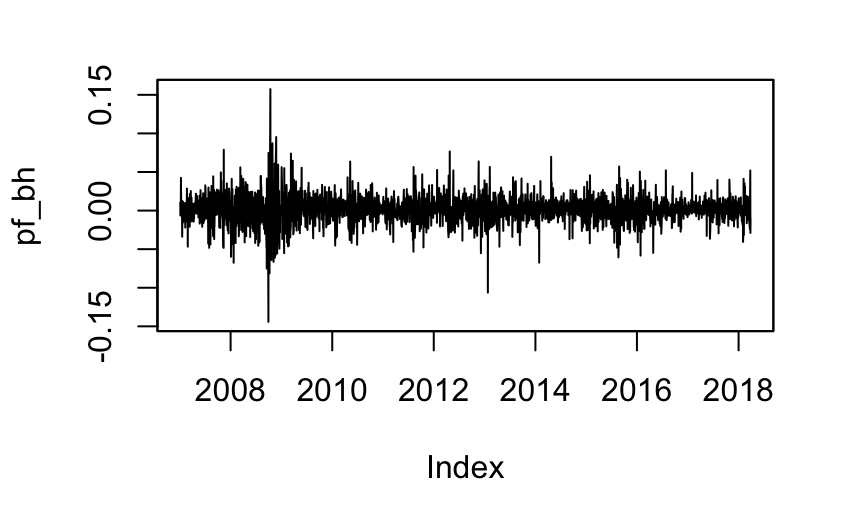

```r
# Create the weights
eq_weights <- c(0.5, 0.5)
# Create a portfolio using buy and hold
pf_bh <- Return.portfolio(R = returns, weights = eq_weights)
# Create a portfolio rebalancing monthly
pf_rebal <- Return.portfolio(R = returns, weights = eq_weights, rebalance_on="months")
# Plot the time-series
plot.zoo(pf_bh)
```

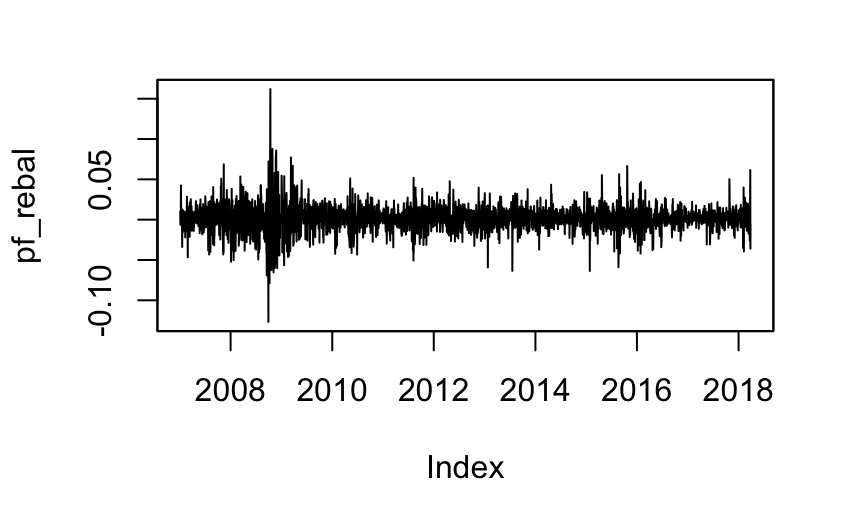

```r
plot.zoo(pf_rebal)
```

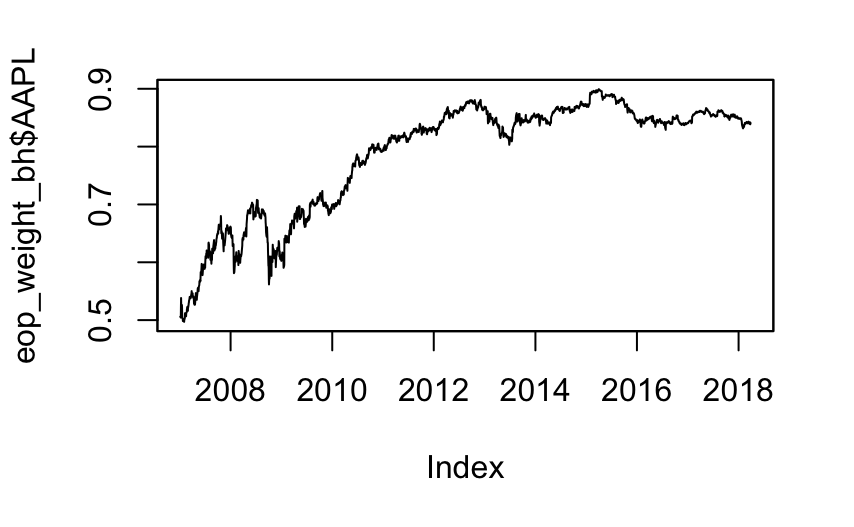

```r
# Create the weights
eq_weights <- c(.5,.5)
# Create a portfolio using buy and hold
pf_bh <- Return.portfolio(returns, weights = eq_weights, verbose=T )
# Create a portfolio that rebalances monthly
pf_rebal <- Return.portfolio(returns, weights = eq_weights, rebalance_on = "months", verbose=T )
# Create eop_weight_bh
eop_weight_bh <- pf_bh$EOP.Weight
# Create eop_weight_rebal
eop_weight_rebal <- pf_rebal$EOP.Weight
# Plot end of period weights
# par(mfrow = c(2, 1), mar=c(2, 4, 2, 2))
plot.zoo(eop_weight_bh$AAPL)
```

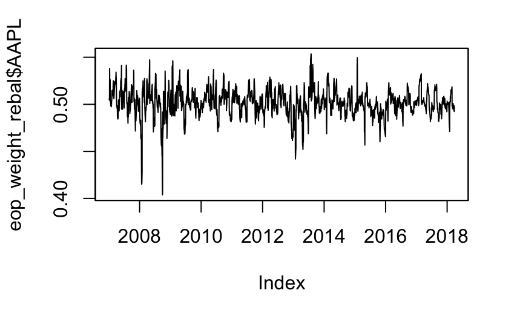

```r
plot.zoo(eop_weight_rebal$AAPL)
```

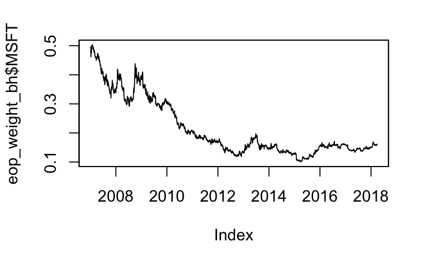

```r
plot.zoo(eop_weight_bh$MSFT)
```

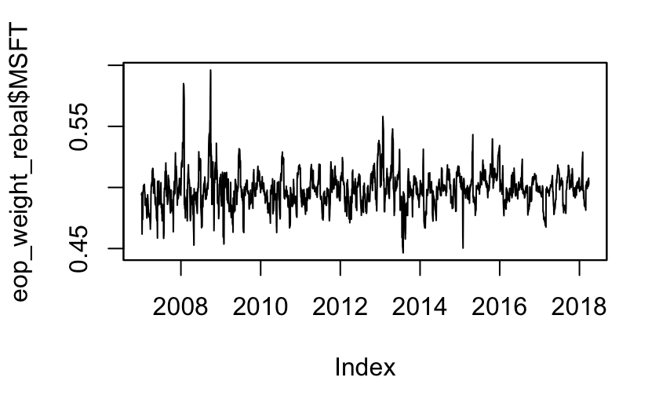

```r
plot.zoo(eop_weight_rebal$MSFT)
```

### Reward vs. Risk and the Sharpe Ration

- Mean return

$$\hat{\mu} = \frac{R_1+R_2+...+R_T}{T}$$
- De-meaned return

$$R_i - \hat{\mu}$$
- Portfolio variance

$$\hat{\sigma}^2 = \frac{(R_1 - \hat{\mu})^2+(R_2 - \hat{\mu})^2+...+(R_T - \hat{\mu})^2}{T-1}$$
- Portfolio volatility (standard deviation)

$$\hat{\sigma} = \sqrt{\hat{\sigma}^2}$$
- Geometric Mean Return

$$GeometricMean = \bigg[ (1+R_1)*(1+R_1) *... * (1+R_T) \bigg]^{\frac{1}{T}} -1$$
– Example: +50% and -50% return

$$GeometricMean = \bigg[ (1+0.5)*(1-0.5) \bigg]^{\frac{1}{2}} -1
\\
= 0.75^{\frac{1}{2}} - 1
\\
= -13.4\%$$

```r
sp500 <- GSPC$GSPC.Adjusted
colnames(sp500) <- c("GSPC")
sp500_monthly <- to.monthly(sp500, OHLC=F)
head(sp500_monthly, n=2)
```

```
            GSPC
Jan 2007 1438.24
Feb 2007 1406.82
```

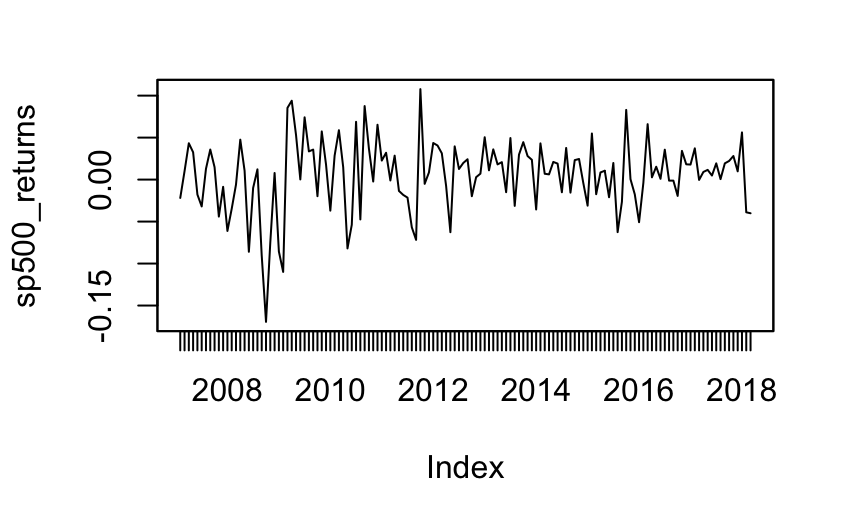

```r
sp500_returns <- Return.calculate(sp500_monthly)
sp500_returns <- sp500_returns[-1]
# Time series plot
plot.zoo(sp500_returns)
```

```r
# Produce the year x month table
table.CalendarReturns(sp500_returns)
```

|  | Jan | Feb | Mar | Apr | May | Jun | Jul | Aug | Sep | Oct | Nov | Dec | GSPC |
| --- | --- | --- | --- | --- | --- | --- | --- | --- | --- | --- | --- | --- | --- |
| 2007 | NA | -2.2 | 1.0 | 4.3 | 3.3 | -1.8 | -3.2 | 1.3 | 3.6 | 1.5 | -4.4 | -0.9 | 2.1 |
| 2008 | -6.1 | -3.5 | -0.6 | 4.8 | 1.1 | -8.6 | -1.0 | 1.2 | -9.1 | -16.9 | -7.5 | 0.8 | -38.5 |
| 2009 | -8.6 | -11.0 | 8.5 | 9.4 | 5.3 | 0.0 | 7.4 | 3.4 | 3.6 | -2.0 | 5.7 | 1.8 | 23.5 |
| 2010 | -3.7 | 2.9 | 5.9 | 1.5 | -8.2 | -5.4 | 6.9 | -4.7 | 8.8 | 3.7 | -0.2 | 6.5 | 12.8 |
| 2011 | 2.3 | 3.2 | -0.1 | 2.8 | -1.4 | -1.8 | -2.1 | -5.7 | -7.2 | 10.8 | -0.5 | 0.9 | 0.0 |
| 2012 | 4.4 | 4.1 | 3.1 | -0.7 | -6.3 | 4.0 | 1.3 | 2.0 | 2.4 | -2.0 | 0.3 | 0.7 | 13.4 |
| 2013 | 5.0 | 1.1 | 3.6 | 1.8 | 2.1 | -1.5 | 4.9 | -3.1 | 3.0 | 4.5 | 2.8 | 2.4 | 29.6 |
| 2014 | -3.6 | 4.3 | 0.7 | 0.6 | 2.1 | 1.9 | -1.5 | 3.8 | -1.6 | 2.3 | 2.5 | -0.4 | 11.4 |
| 2015 | -3.1 | 5.5 | -1.7 | 0.9 | 1.0 | -2.1 | 2.0 | -6.3 | -2.6 | 8.3 | 0.1 | -1.8 | -0.7 |
| 2016 | -5.1 | -0.4 | 6.6 | 0.3 | 1.5 | 0.1 | 3.6 | -0.1 | -0.1 | -1.9 | 3.4 | 1.8 | 9.5 |

[output cut: 2 more lines]

```r
# Compute the mean monthly returns
mean(sp500_returns)
```

```
[1] 0.005358624
```

```r
# Compute the geometric mean of monthly returns
mean.geometric(sp500_returns)
```

```
                      GSPC
Geometric Mean 0.004442769
```

```r
# Compute the standard deviation
sd(sp500_returns)
```

```
[1] 0.0425496
```

- (Annualized) Sharpe Ration $R_p$ = Portfolio Return $R_f$ = Risk Free Rate $\sigma$ = Portfolio Volatility
  $$SharpeRation = \frac{R_p - R_f}{\sigma_p}$$

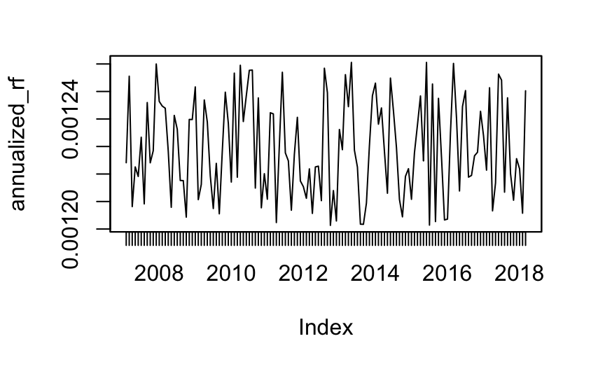

```r
random <- runif(length(sp500_returns), min =0, max = 0.5)*0.00001 + 0.0001
rf <- xts(random, order.by = index(sp500_returns))
# Compute the annualized risk free rate
annualized_rf <- (1 + rf)^12 - 1
# Plot the annualized risk free rate
plot.zoo(annualized_rf)
```

```r
# Compute the series of excess portfolio returns
sp500_excess <- sp500_returns - rf
# Compare the mean
mean(sp500_excess)
```

```
[1] 0.005256232
```

```r
mean(sp500_returns)
```

```
[1] 0.005358624
```

```r
# Compute the Sharpe ratio
sp500_sharpe <- mean(sp500_excess) / sd(sp500_returns)
sp500_sharpe
```

```
[1] 0.1235319
```

```r
# Compute the annualized mean
ar <- Return.annualized.excess(sp500_returns, Rb=0)
ar
```

```
                        GSPC
Annualized Return 0.05463544
```

```r
# Compute the annualized standard deviation
astd <- StdDev.annualized(sp500_returns)
astd
```

```
                                   GSPC
Annualized Standard Deviation 0.1473961
```

```r
# Compute the annualized Sharpe ratio: ann_sharpe
ann_sharpe <- ar/astd
ann_sharpe
```

```
                       GSPC
Annualized Return 0.3706708
```

```r
# Compute all of the above at once using table.AnnualizedReturns()
table.AnnualizedReturns(sp500_returns)
```

|  | GSPC |
| --- | --- |
| Annualized Return | 0.0546 |
| Annualized Std Dev | 0.1474 |
| Annualized Sharpe (Rf=0%) | 0.3707 |

### Rolling Performance

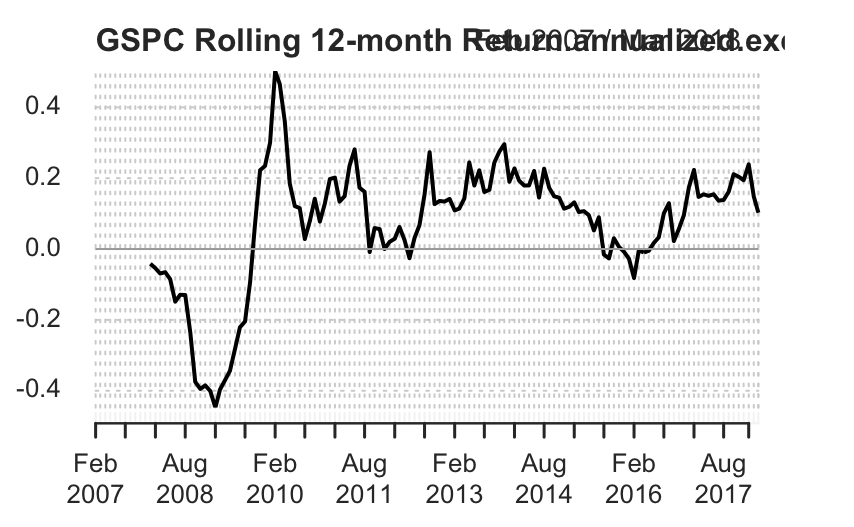

```r
# Calculate the mean, volatility, and sharpe ratio of sp500_returns
returns_ann <- Return.annualized.excess(sp500_returns, 0)
sd_ann <- StdDev.annualized(sp500_returns)
sharpe_ann <- SharpeRatio.annualized(sp500_returns, rf)
# Plotting the 12-month rolling annualized mean
chart.RollingPerformance(R = sp500_returns, width = 12, FUN = "Return.annualized.excess", Rb=0)
abline(h = returns_ann)
```

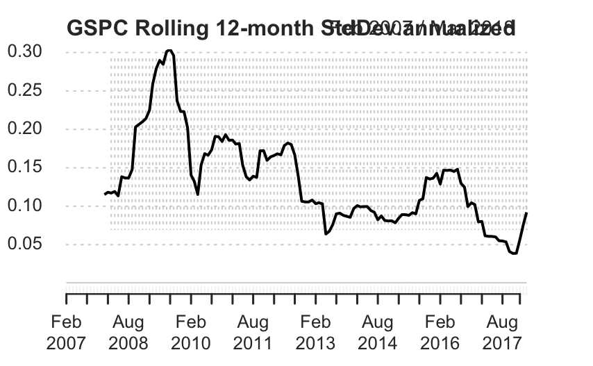

```r
# Plotting the 12-month rolling annualized standard deviation
chart.RollingPerformance(R = sp500_returns, width = 12, FUN = "StdDev.annualized")
abline(h = sd_ann)
```

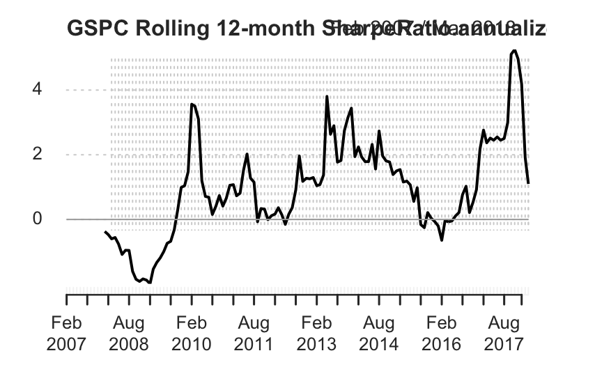

```r
# Plotting the 12-month rolling annualized Sharpe ratio
chart.RollingPerformance(R = sp500_returns, Rf=rf, width = 12, FUN = "SharpeRatio.annualized")
abline(h = sharpe_ann)
```

[figure not shown]

```r
# Fill in window for 2008
sp500_2008 <- window(sp500_returns, start = "2008-01-01", end = "2008-12-31")
# Create window for 2014
sp500_2014 <- window(sp500_returns, start = "2014-01-01", end = "2014-12-31")
# Plotting settings
par(mfrow = c(1, 2) , mar=c(3, 2, 2, 2))
names(sp500_2008) <- "sp500_2008"
names(sp500_2014) <- "sp500_2014"
# Plot histogram of 2008
chart.Histogram(sp500_2008, methods = c("add.density", "add.normal"))
# Plot histogram of 2014
chart.Histogram(sp500_2014, methods = c("add.density", "add.normal"))
```

- Semi-Deviation (subset of returns below the mean)

$$SemiDev = \sqrt{\frac{(Z_1-\mu)^2+(Z_2-\mu)^2+...+(Z_n-\mu)^2}{n}}$$

```r
SemiDeviation(sp500_returns)
```

```
                     GSPC
Semi-Deviation 0.03260378
```

- Value-at-Risk & Expected Shortfall

```r
# Calculate the value at risk
VaR(sp500_returns, 0.025)
VaR(sp500_returns, 0.05)


# Calculate the expected shortfall
ES(sp500_returns, 0.025)
ES(sp500_returns, 0.05)
```

[output not shown]

- Skewness

```r
skewness(sp500_returns)
```

[output not shown]

- Kurtosis

```r
kurtosis(sp500_returns)
```

[output not shown]

#### Drawdowns due to buying high, selling low

The volatility, semi-deviation, value-at-risk, and expected shortfall are all measures that describe risk over 1 period. These metrics do not do a great job at describing the worst case risk of buying at a peak, and selling at a trough. This sort of risk can be quantified by analyzing the portfolio’s drawdowns, or peak-to-trough decline in cumulative returns.

```r
# Table of drawdowns
table.Drawdowns(sp500_returns, drop = F)
```

[output not shown]

## Portfolio Performance Evaluation

Return –> Random Variable –> Expectation

#### Portfolio return

$$PortfolioReturn = w_1R_1+w_2R_2+...+w_nR_n
\\
\mathbf{E}[P] = w_1\mathbf{E}[R_1] + w_2\mathbf{E}[R_2] + ... + w_n\mathbf{E}[R_n]$$
#### Variance of Portfolio Return
$$var(P) = \mathbf{E}\Big[\big(P - \mathbf{E}[P]^2\big)\Big] = w_1^2* var(R_1) \\
+ w_2 * var(R_2) \\
+ 2 * w_1 * w_2 * cov(R_1,R_2)$$
#### Covariance between $R_!$ and $R_2$
$$cov(R_1,R_2) = \mathbf{E}\Big[\big(R_1 - \mathbf{E}[R_1]\big)\big(R_2 - \mathbf{E}[R_2]\big)\Big] \\
= StdDev(R_1) * StdDev(R_2) * corr(R_1,R_2)$$
## Drivers of Performance

### Driver 1: The assets’ individual performance

```r
returns_6040 = 0.6 * returns$AAPL + 0.4 * returns$MSFT
all.equal(mean(returns_6040), 0.6 * mean(returns$AAPL) + 0.4 * mean(returns$MSFT))
```

```
[1] TRUE
```

### Driver 2: The choice of portfolio weights

Investors can optimize the choice of weight to obtain the highest risk-adjusted return, as measured by the portfolio Sharpe ratio.

In the special case of investing the total portfolio value in only two assets, there is only one weight to determine, because the weight on the second asset equals one minus the weight of the first asset.

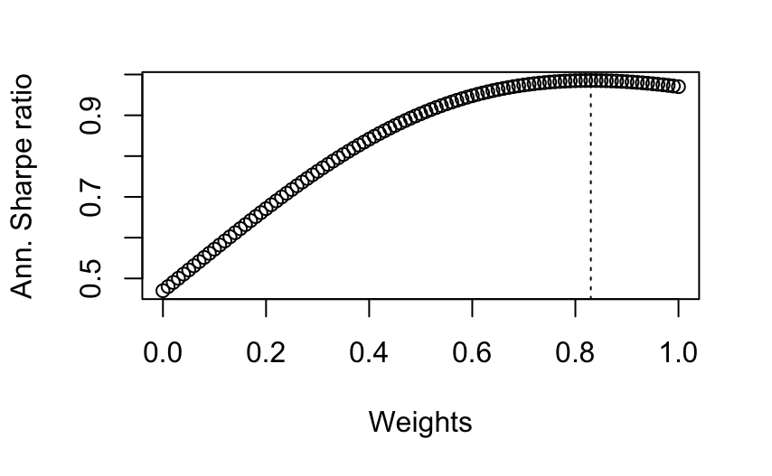

```r
# Create a grid
grid <- seq(0, 1, 0.01)
# Initialize an empty vector for sharpe ratios
vsharpe <- rep(NA, times = length(grid))
# Create a for loop to calculate sharpe ratios
for(i in 1:length(grid)) {
    weight <- grid[i]
    preturns <- weight * returns$AAPL + (1 - weight) * returns$MSFT
    vsharpe[i] <- SharpeRatio.annualized(preturns)
}
# Plot weights and sharpe ratio
plot(grid, vsharpe, xlab = "Weights", ylab = "Ann. Sharpe ratio")
abline(v = grid[vsharpe == max(vsharpe)], lty = 3)
```

### Driver 3: The correlation between the asset returns

The third driver of portfolio performance is the correlation between the asset returns. Generally speaking, the correlation tells you how two asset returns tend to move together.

The correlation of assets has important consequences in overall portfolio performance. This correlation is important because it can reduce volatility through diversification, or reducing overall correlation. In fact, the lower the correlation, the more succesful the portfolio tends to be in regards to partially offsetting large losses in one asset with only a minor loss, or even a gain, in another asset.

In the extreme case of two identical asset returns, the correlation will be 1, and there is no diversification potential. In the other extreme case where, if one asset return is above average, and the other is almost always below average, the correlation is negative. The correlation is 0 when the asset returns are linearly independent of each other. Note that interdependency can still exist on a non-linear level even when the correlation is 0.

#### Interpreting correlation

In this exercise you will learn 3 new functions from the PerformanceAnalytics package: **chart.Scatter()**, **chart.Correlation()**, and **chart.RollingCorrelation()**.

[figure not shown]

```r
# Create a scatter plot
chart.Scatter(returns$MSFT, returns$AAPL, type = "p")
```

```r
# Find the correlation
cor(returns$AAPL, returns$MSFT)
```

```
          MSFT
AAPL 0.4713825
```

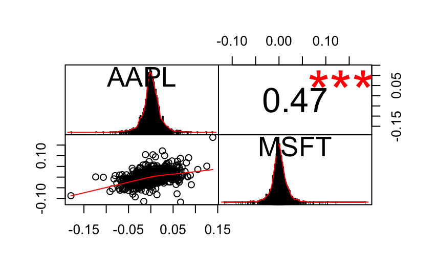

```r
# Merge returns_equities and returns_bonds
returns <- merge(returns$AAPL, returns$MSFT)
# Find and visualize the correlation using chart.Correlation
chart.Correlation(returns)
```

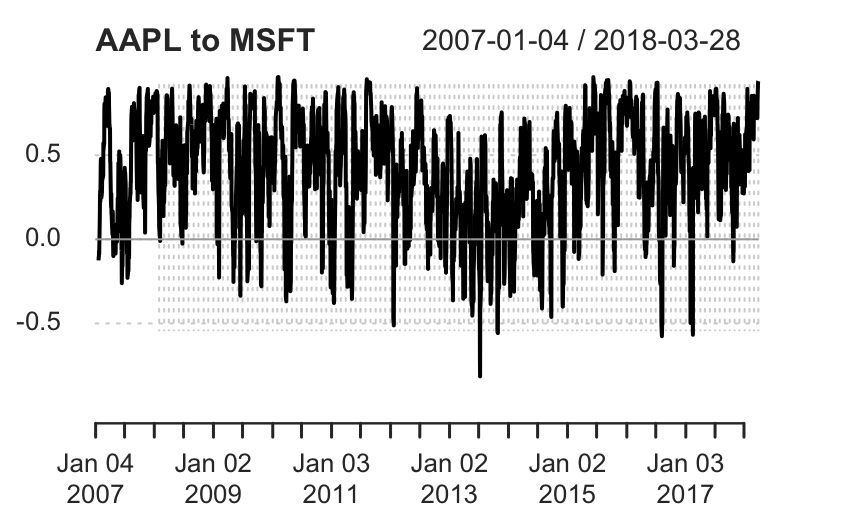

```r
# Visualize the rolling estimates using chart.RollingCorrelation
chart.RollingCorrelation(returns$AAPL, returns$MSFT)
```

### Matrix Notation

$\mathbf{w}$: the $N \times 1$ column-matrix of portfolio weights
$$\mathbf{w} =
\begin{bmatrix}
w_1 \\ w_2 \\ \vdots \\ w_N
\end{bmatrix}$$
$\mathbf{R}$: the $N \times 1$ column-matrix of asset returns
$$\mathbf{R} =
\begin{bmatrix}
R_1 \\ R_2 \\ \vdots \\ R_N
\end{bmatrix}$$
$\mathbf{\mu}$: the $N \times 1$ column-matrix of expected returns
$$\mathbf{\mu} =
\begin{bmatrix}
\mu_1 \\ \mu_2 \\ \vdots \\ \mu_N
\end{bmatrix}$$

$\mathbf{\Sigma}$: the $N \times N$ cavariance matrix of the $N$ asset returns

$$\mathbf{\Sigma} =
\begin{pmatrix}
\sigma_{11}^2 & \sigma_{12} & \cdots & \sigma_{1N} \\
\sigma_{21} & \sigma_{22}^2 & \cdots & \sigma_{2N} \\
\vdots & \vdots & \ddots & \vdots \\
\sigma_{N1} & \sigma_{N2} & \cdots & \sigma_{NN}^2
\end{pmatrix}$$
### General Case - Portfolio Return
$$\mathbf{w}'\mathbf{R}$$

- Portfolio Expected Return
  $$\mathbf{w}'\mathbf{\mu}$$
- Portfolio Variance
  $$\mathbf{w}'\mathbf{\Sigma}\mathbf{w}$$

```r
# Create a vector of returns
means <- apply(returns, 2, "mean")

# Create a vector of standard deviation
sds <- apply(returns, 2, "sd")

# Create a scatter plot
plot(sds, means)
text(sds, means, labels = colnames(returns), cex = 0.7)
abline(h = 0, lty = 3)
```

[output not shown]

```r
# Create a matrix with variances on the diagonal
diag_cov <- diag(sds^2)

# Create a covariance matrix of returns
cov_matrix <- cov(returns)

# Create a correlation matrix of returns
cor_matrix <- cor(returns)

# Verify covariances equal the product of standard deviations and correlation
current <- cor_matrix[1,2] * sds[1] * sds[2]
names(current) <- NULL
all.equal(cov_matrix[1,2], current[1])
```

[output not shown]

```r
# Create a weight matrix w
w <- as.matrix(c(.5,.5))
# Create a matrix of returns
mu <- as.matrix(means)
# Calculate portfolio mean monthly returns
t(w) %*% mu
```

```
             [,1]
[1,] 0.0009513917
```

```r
# Calculate portfolio volatility
sqrt(t(w) %*% cov_matrix %*% w)
```

```
           [,1]
[1,] 0.01604969
```

### Risk Budgeting

How much of the portfolio risk is caused by individual positions?

Capital Allocation Budget vs Portfolio Volatility Risk

- Portofolio Volatility in Risk Contribution ($RC$)

$$Portfolio Volatility = \sum_{i=1}^N RC_i \\
\text{where: } RC_i = \frac{w_i(\Sigma w)_i}{\sqrt{w'\Sigma w}}$$
- Percentage Risk Contribution
$$\% RC_i = \frac{RC_i}{PortfolioVolatility} \\
\text{where: } \sum_{i=1}^N \%RC_i =1$$
Relatively more risky assets: $\%RC_i \gt w_i$ Relatively less risky assets: $\%RC_i \lt w_i$

```r
# Create portfolio weights
weights <- c(.5,.5)
# Create volatility budget
vol_budget <- StdDev(returns, portfolio_method = "component", weights = weights)
# Make a table of weights and risk contribution
weights_percrisk <- cbind(weights, vol_budget$pct_contrib_StdDev)
colnames(weights_percrisk) <- c("weights", "perc vol contrib")
# Print the table
weights_percrisk
```

```
     weights perc vol contrib
AAPL     0.5        0.5498808
MSFT     0.5        0.4501192
```

## Portfolio Optimization (Markowitz)

### Objectives

- Maximize expected return
- Minimize variance
- Maximize Sharpe Ration

### A note on contraints

- Only positive weights
- Weights sum to 1 (fully invested)
- Portfolio expected return equals a target value

**No other portfolio exists with a higher expected return at the same or lowe level of volatility (no portfolio on the upper left when y=meanPortfolioReturn and x=volatility)**

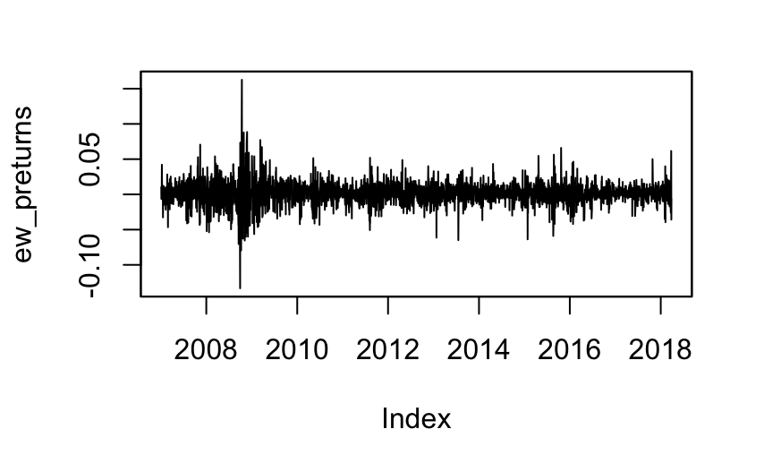

```r
# Create a vector of row means
ew_preturns <- rowMeans(returns)
# Cast the numeric vector back to an xts object
ew_preturns <- xts(ew_preturns, order.by = time(returns))
# Plot ew_preturns
plot.zoo(ew_preturns)
```

#### Finding the mean-variance efficient portfolio

```r
# Load tseries
library(tseries)
# Create an optimized portfolio of returns
opt <- portfolio.optim(returns)
# Create pf_weights
pf_weights <- opt$pw
# Assign asset names
names(pf_weights) <- colnames(returns)
# Select optimum weights opt_weights
opt_weights <- pf_weights[pf_weights>= 0.01]
opt_weights
```

```
AAPL MSFT
 0.5  0.5
```

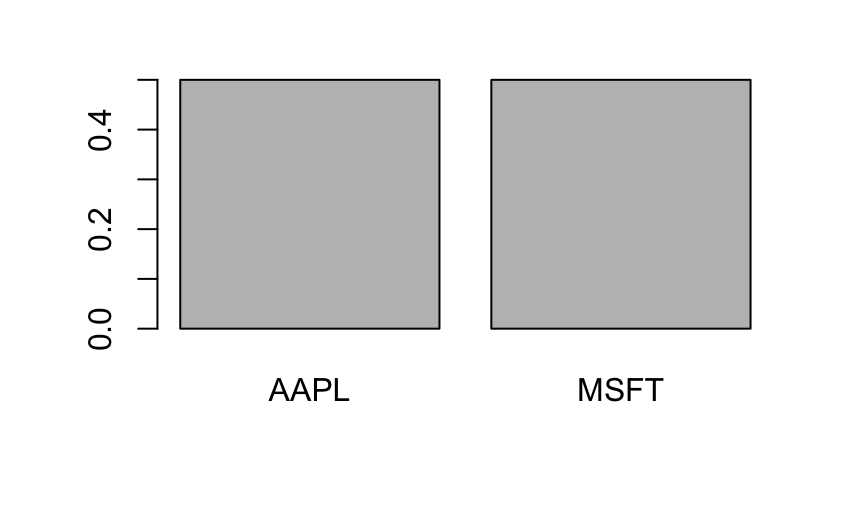

```r
# Barplot of opt_weights
barplot(opt_weights)
```

```r
# Print expected portfolio return and volatility
opt$pm
```

```
[1] 0.0009513917
```

```r
opt$ps
```

```
[1] 0.01604969
```

#### Effect of the return target

```r
# Create portfolio with target return of average returns
pf_mean <- portfolio.optim(returns, pm = mean(returns))
# Create portfolio with target return 10% greater than average returns
pf_10plus <- portfolio.optim(returns, pm = 1.1 * mean(returns))
# Print the standard deviations of both portfolios
pf_mean$ps
```

```
[1] 0.01604969
```

```r
pf_10plus$ps
```

```
[1] 0.01676841
```

```r
# Calculate the proportion increase in standard deviation
(pf_10plus$ps - pf_mean$ps) / (pf_mean$ps)
```

```
[1] 0.04478078
```

#### Imposing weight constraints

Investors are often constrained by the maximum values allowed for the portfolio weights. These constraints can actually be an advantage. The advantage of a maximum weight constraint is that the subsequent portfolio will be less concentrated in certain assets. There is a disadvantage to this though. The disadvantage is that the same target return may no longer be possible or will be obtained at the expense of a higher volatility.

```r
# Create vectors of maximum weights
max_weights1 <- rep(1, ncol(returns))
max_weights2 <- rep(0.8, ncol(returns))
max_weights3 <- rep(0.6, ncol(returns))
# Create an optimum portfolio with max weights of 100%
opt1 <- portfolio.optim(returns, reshigh = max_weights1)
# Create an optimum portfolio with max weights of 10%
opt2 <- portfolio.optim(returns, reshigh = max_weights2)
# Create an optimum portfolio with max weights of 5%
opt3 <- portfolio.optim(returns, reshigh = max_weights3)
# Calculate how many assets have a weight that is greater than 1% for each portfolio
sum(opt1$pw > .01)
```

```
[1] 2
```

```r
sum(opt2$pw > .01)
```

```
[1] 2
```

```r
sum(opt3$pw > .01)
```

```
[1] 2
```

```r
# Print portfolio volatilites
opt1$ps
```

```
[1] 0.01604969
```

```r
opt2$ps
```

```
[1] 0.01604969
```

```r
opt3$ps
```

```
[1] 0.01604969
```

### The Efficient Frontier

#### Computing the efficient frontier using a grid of target returns

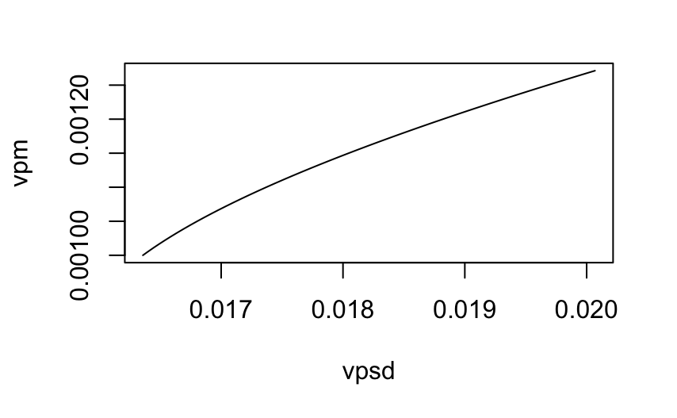

```r
# Calculate each stocks mean returns
stockmu <- colMeans(returns)
# Create a grid of target values
grid <- seq(0.001, max(stockmu), length.out = 50)
# Create empty vectors to store means and deviations
vpm <- vpsd <- rep(NA, length(grid))
# Create an empty matrix to store weights
mweights <- matrix(NA, 50, 2)
# Create your for loop
for(i in 1:length(grid)) {
  opt <- portfolio.optim(x = returns , pm = grid[i])
  vpm[i] <- opt$pm
  vpsd[i] <- opt$ps
  mweights[i, ] <- opt$pw
}
plot.zoo(vpsd, vpm, type="l")
```

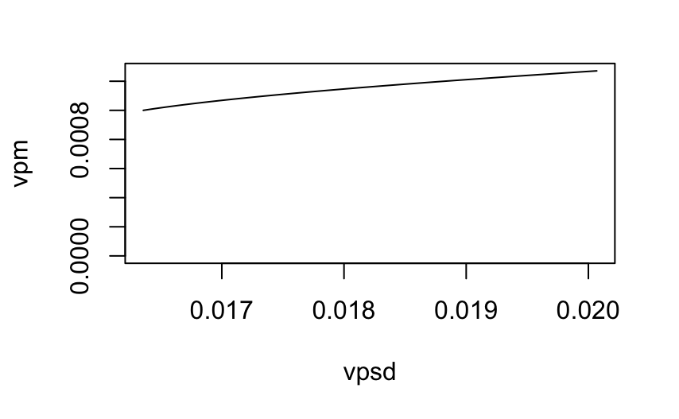

```r
plot.zoo(vpsd, vpm, type="l", ylim = c(0, max(vpm)))
```